# Logistic Regression

## Introduction

- Data example
- Simple logistic regression analysis
- Multiple logistic regression analysis

## Data example

We will use the same data, **fev**, used in the lecture ‘06_TestsOnMeans’. This data have `fev` measuring lung function in children who are smokers or non-smokers. Smoking tends to impair lung function.

- Important variables we use in this lecture:
  - **sex**: subject gender (1 = male, 2 = female)
  - **smoke**: smoke smoking habits (1 = yes, 2 = no)
  - **age**: subject age at time of measurement (years)
  - **fev**: measured FEV (liters per second)
  - **height**: subject height at time of measurement (inches)

```r
#fev=read.csv("./data/fev.csv",header=TRUE,row.names=1)
fev <- read.csv("https://raw.githubusercontent.com/couthcommander/sip_computing/main/labs/fev.csv",header=TRUE,row.names=1)
fev$sex=ifelse(fev$sex==1,"male","female")
fev$smoke=factor(ifelse(fev$smoke==1,"yes","no"))

head(fev)
```

```
##   age   fev height    sex smoke
## 1   9 1.708   57.0 female    no
## 2   8 1.724   67.5 female    no
## 3   7 1.720   54.5 female    no
## 4   9 1.558   53.0   male    no
## 5   9 1.895   57.0   male    no
## 6   8 2.336   61.0 female    no
```

## Simple logistic regression

**Question**: Does smoking associated with age?

### Logistic regression assumptions

- The outcome is a binary or dichotomous variable: e.g., yes vs. no, positive vs. negative, 1 vs. 0.
- The observations are independent.
- There is a linear relationship between the logit of $\mbox{Pr}(Y=1 | X)$ and predictors: $\mbox{logit}\left\{\mbox{Pr}(Y=1 | X)\right\} = X \beta$.

### Data visulization

```r
table(fev$smoke)
```

```
##
##  no yes
## 589  65
```

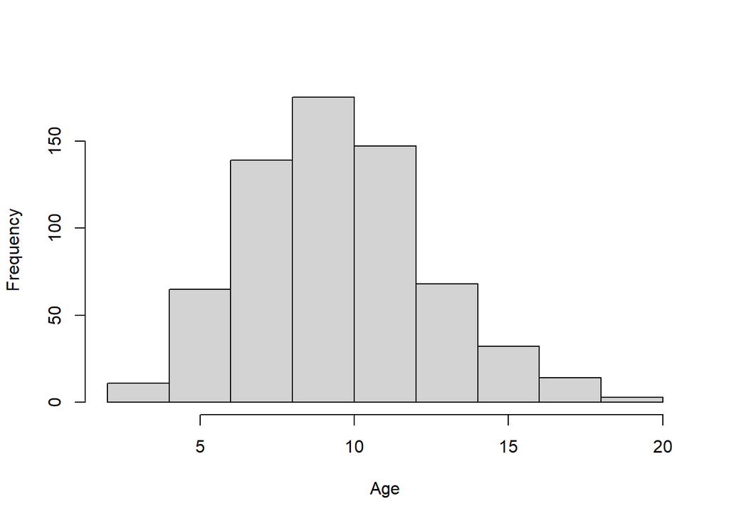

```r
hist(fev$age, main="", xlab="Age")
```

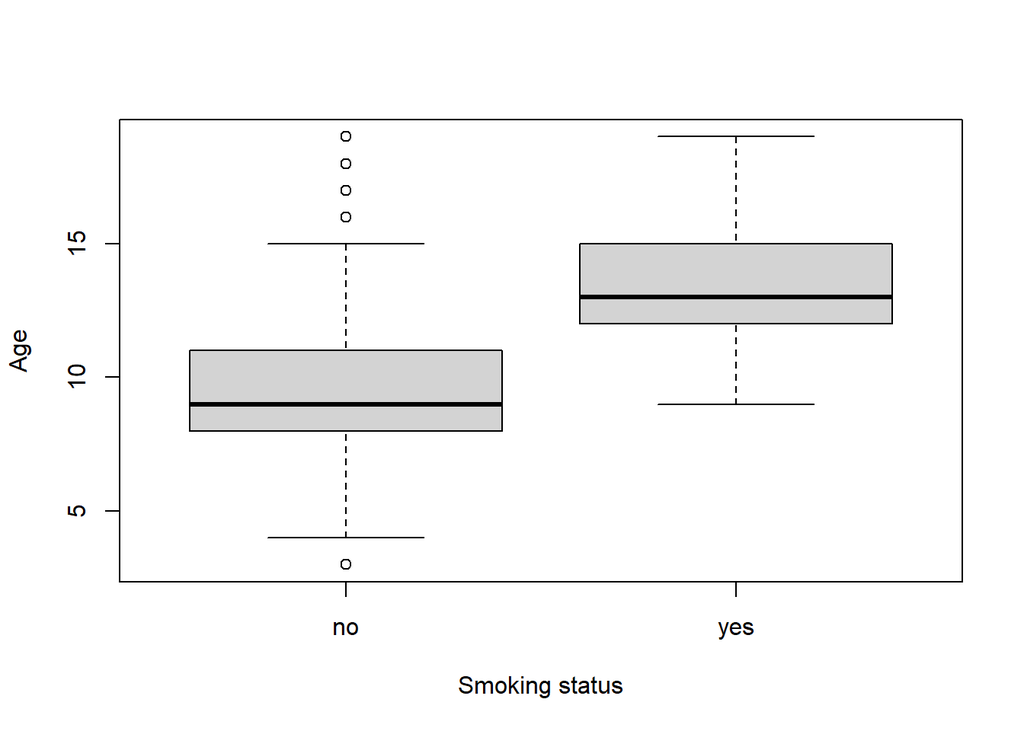

```r
boxplot(fev$age ~ fev$smoke, main="", xlab="Smoking status", ylab="Age")
```

### Perform logistic regression analysis

$\mbox{logit}\left\{\mbox{Pr}(y=1 | X)\right\} = b_0 + b_1 age$, where $y = 1$ if smoking is “yes”; otherwise $y = 0$.

```r
modelResult <- glm(smoke ~ age, data = fev, family = "binomial")
summary(modelResult)
```

```
##
## Call:
## glm(formula = smoke ~ age, family = "binomial", data = fev)
##
## Deviance Residuals:
##     Min       1Q   Median       3Q      Max
## -1.8204  -0.4120  -0.2574  -0.1595   2.6170
##
## Coefficients:
##             Estimate Std. Error z value Pr(>|z|)
## (Intercept) -7.74391    0.70890 -10.924   <2e-16 ***
## age          0.48364    0.05513   8.773   <2e-16 ***
## ---
## Signif. codes:  0 '***' 0.001 '**' 0.01 '*' 0.05 '.' 0.1 ' ' 1
##
## (Dispersion parameter for binomial family taken to be 1)
##
##     Null deviance: 423.45  on 653  degrees of freedom
## Residual deviance: 318.56  on 652  degrees of freedom
## AIC: 322.56
##
## Number of Fisher Scoring iterations: 6
```

Interpretation of results:

- The *Coefficients* are estimates of model parameters: the intercept ($b_0$) is -7.74391 and age ($b_1$) is 0.48364.
- The estimated regression equation can be written as follow: $\mbox{log}\left (\frac{Pr(y=1 | X)}{1-Pr(y=1 | X)}\right) = -7.74391 + 0.48364 \; \mbox{age}$
- $Pr(y=1 | X)$ = $\frac{e^{(-7.74391 \: + \: 0.48364 \: age)}}{1+e^{(-7.74391 \: + \: 0.48364 \: age)}}$, where $Pr(y=1 | X)$ is the probability of being a smoker at a specific age.

### Predict new data

```r
newData <- data.frame(age = c(Subject1=10,Subject2=50))
predictionResult=predict.glm(modelResult, newData,type ="response") #probabilities
predictionResult
```

```
##   Subject1   Subject2
## 0.05178351 0.99999993
```

### Odds ratio

- Let $p = Pr(y=1 | X)$. The $\frac{p}{1-p}$ is called odds, or odds of success, which is the ratio of “successes” to “non-successes”. It reflects the likelihood that the event will occur. $\mbox{logit} \left \{ Pr(y=1 | X) \right \} = \mbox{logit}(p) = \mbox{log}\left (\frac{p}{1-p}\right)$ is called log odds.
- Odds ratio (OR) is the ratio of two odds:
  $$\frac{\left (p_1/(1-p_1)\right)}{\left (p_2/(1-p_2)\right)}$$
- It represents the ratio of the odds that an event will occur (for example, being a smoker) in one scenario (for example, age = 2), $p_1$, compared to the odds of the event occurring (being a smoker) in another scenario (for example, age = 1), $p_2$. The OR in a logistic regression measures the association between the outcome variable (being smoker) and a predictor variable (age).
- Based on the equation from the model, log($\frac{p}{1-p}$) = -7.74391 + 0.48364 x age:
  - We can estimate the OR being a smoker at Age1 (e.g., age = 2) compared to Age2 (e.g., age = 1):

  $e^{(-7.74391 + 0.48364*Age1)}/e^{(-7.74391 + 0.48364*Age2)}$ = $e^{(-7.74391 + 0.48364*Age1)-(7.74391 + 0.48364*Age2)}$ = $e^{0.48364*(Age1-Age2)}$
  - We typically report the OR by taking exponentiation of the coefficient. $e^{0.48364}=1.62$. It indicates that with one year of age increase, the odds of being a smoker will increase by a factor of 1.62.

```r
#odds ratio
exp(coefficients(modelResult))
```

```
##  (Intercept)          age
## 0.0004333759 1.6219666490
```

```r
#CI for odds ratio
exp(confint(modelResult))
```

```
##                    2.5 %      97.5 %
## (Intercept) 9.957013e-05 0.001616879
## age         1.462364e+00 1.816425554
```

## Multiple logistic regression

**Question**: Does smoking associated with age, height, and sex?

### Data visulization

```r
table(fev$sex,fev$smoke)
```

```
##
##           no yes
##   female 279  39
##   male   310  26
```

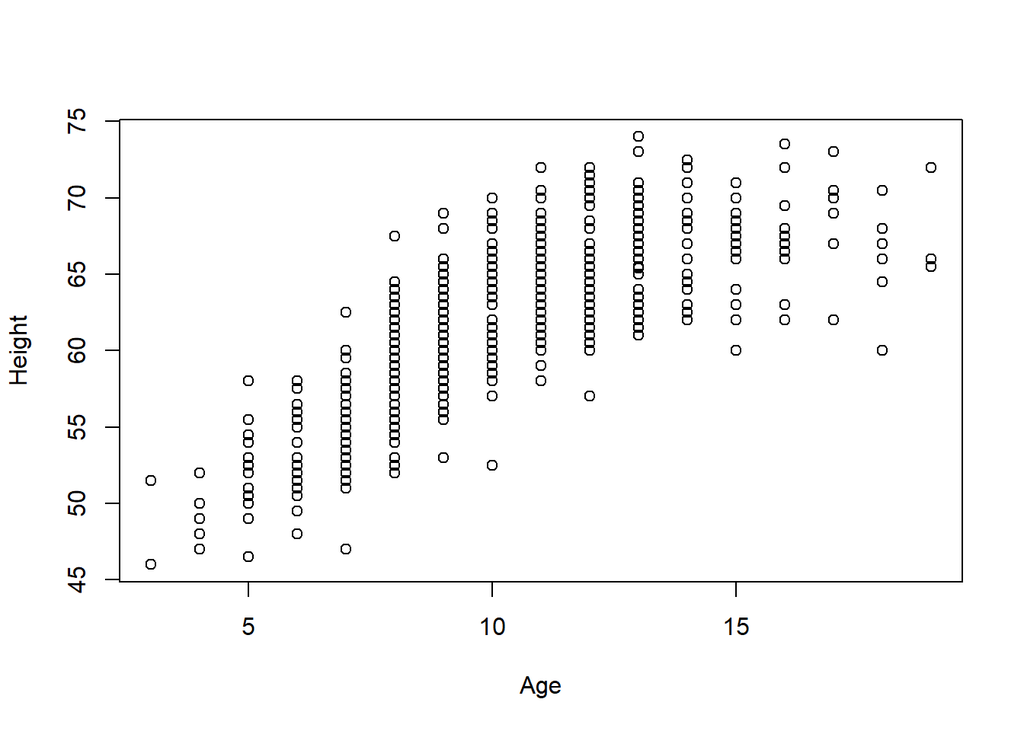

```r
plot(fev[,c("age","height")], xlab="Age", ylab="Height")
```

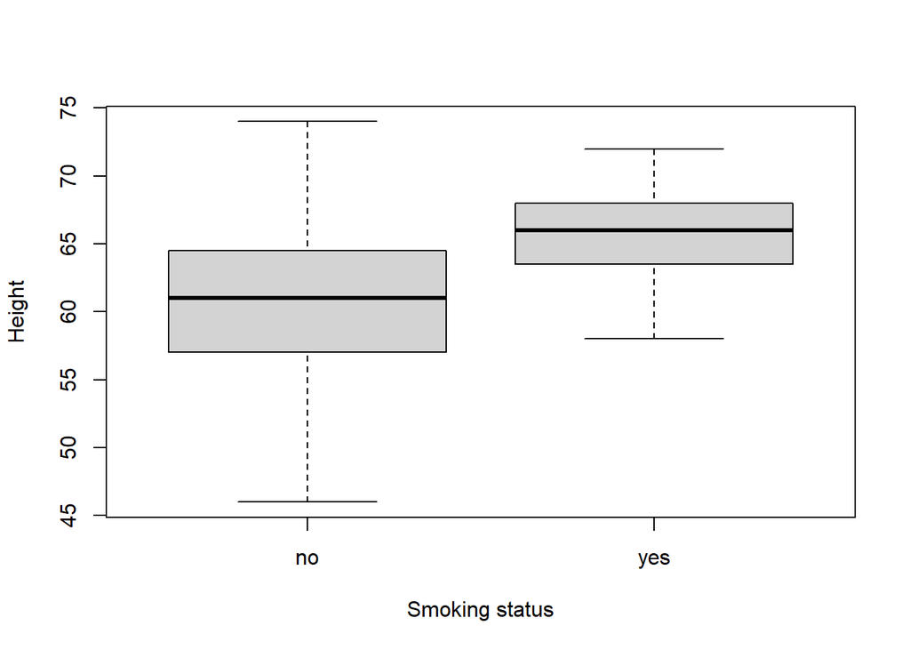

```r
boxplot(fev$height~fev$smoke, xlab="Smoking status", ylab="Height")
```

### Perform logistic regression analysis

```r
modelResult <- glm(smoke ~ age + height + sex, data = fev, family = "binomial")
summary(modelResult)
```

```
##
## Call:
## glm(formula = smoke ~ age + height + sex, family = "binomial",
##     data = fev)
##
## Deviance Residuals:
##      Min        1Q    Median        3Q       Max
## -1.72393  -0.41038  -0.21198  -0.08289   3.12896
##
## Coefficients:
##              Estimate Std. Error z value Pr(>|z|)
## (Intercept) -15.88180    3.12163  -5.088 3.63e-07 ***
## age           0.39395    0.06703   5.877 4.18e-09 ***
## height        0.15182    0.05321   2.853 0.004329 **
## sexmale      -1.35698    0.38219  -3.551 0.000384 ***
## ---
## Signif. codes:  0 '***' 0.001 '**' 0.01 '*' 0.05 '.' 0.1 ' ' 1
##
## (Dispersion parameter for binomial family taken to be 1)
##
##     Null deviance: 423.45  on 653  degrees of freedom
## Residual deviance: 303.03  on 650  degrees of freedom
## AIC: 311.03
##
## Number of Fisher Scoring iterations: 7
```

### Effects of variables

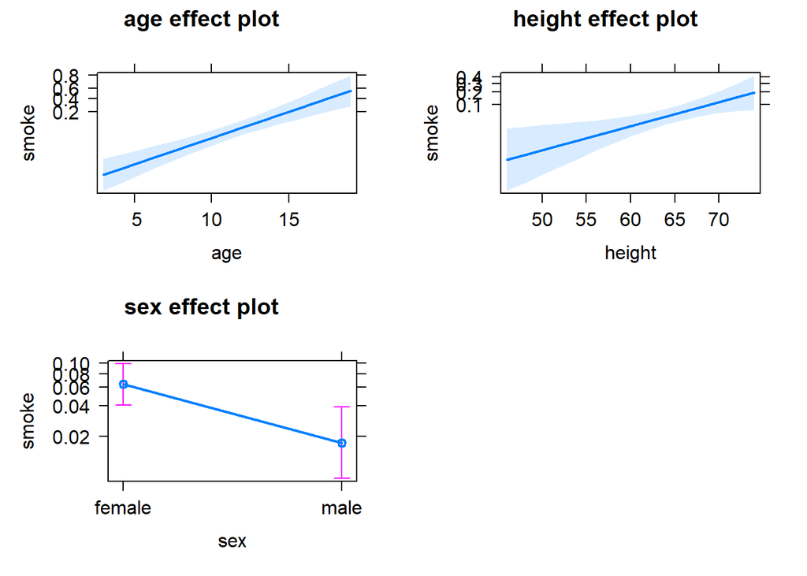

```r
library(effects)
plot(allEffects(modelResult), axes=list(x=list(rug=FALSE)))
```